# Gat201 RNA Seq count analysis 2021-04-24EH

Liz Hughes

24/04/2021

# GAT201 RNA Seq analysis_EHughes

To carry out RNA-Seq I will use the Lexogen Quant Seq 3’ mRNA-Seq library prep kit FWD. This is designed to generate illumina compatible libraries of sequences close to the 3’ end of polyA RNA.

Work flow: Reverse transcription ⇒ Removal of RNA ⇒ Second strand synthesis ⇒ Library amplification ⇒ Sequencing

4 strains: KN99a, KN99 alpha, Gat201 deletion from the Madhani deletion collection (003) and Gat201 disruption from the Bahn collection (004).

2 conditions: RPMI and RPMI+Serum (10%).

2 BioReps and 3 Tech Reps.

A single colony was grown in YPD, 30 degrees, 200rpm for 5 days.

3.5 ml was transferred to 100ml fresh RPMI or RPMI+10% Serum and incubated at 37 degrees, 60rpm.

2ml samples were taken from each rep at time 0hrs, fix and freeze and put at -80 degrees.

At 30 mins, 2hrs and 4hrs 15 ml samples were collected, fix and freeze and put at -80 degrees.

# Load packages used for analysis

```r
library(tidyverse)
library(magrittr)
```

```r
library(cowplot)
library(readxl)
library(pheatmap)
library(GGally)
library(ggrepel)
library(broom)
library(Matrix)
library(dendextend)
theme_set(theme_cowplot(font_size = 12))

geom_diagline <- function(size = 0.5, linetype = "dashed", ...) {
    geom_abline(slope=1, intercept = 0, linetype = linetype, ...)
}
```

# Load count data

```r
counts <- read_tsv("~/Documents/GitHub/CryptoGat201RNASeq_draft/quantseqfwd_EH_050221/counts.txt",
                   comment = "#")
counts
```

```
## # A tibble: 6,795 x 62
##    Geneid     Chr Start   End Strand Length `15_S25_R1_001_al~ `38_S13_R1_001_a~
##    <chr>    <dbl> <dbl> <dbl> <chr>   <dbl>              <dbl>             <dbl>
##  1 CNAG_00~     1 12730 13756 +        1027                184               452
##  2 CNAG_00~     1 14025 16421 -        2397                137               153
##  3 CNAG_00~     1 16427 19850 -        3424                134               210
##  4 CNAG_00~     1 20750 22911 -        2162                206               799
##  5 CNAG_00~     1 24710 26159 -        1450                490              1070
##  6 CNAG_00~     1 26275 28568 +        2294                 67               423
##  7 CNAG_00~     1 28555 32905 -        4351                166               260
##  8 CNAG_00~     1 33086 34879 +        1794                259               121
##  9 CNAG_00~     1 35746 39624 -        3879                197               403
## 10 CNAG_00~     1 40231 42267 +        2037                105                80
## # ... with 6,785 more rows, and 54 more variables: 26_S5_R1_001_aln.bam <dbl>,
## #   55_S38_R1_001_aln.bam <dbl>, 25_S20_R1_001_aln.bam <dbl>,
## #   43_S7_R1_001_aln.bam <dbl>, 44_S49_R1_001_aln.bam <dbl>,
## #   18_S19_R1_001_aln.bam <dbl>, 41_S36_R1_001_aln.bam <dbl>,
## #   50_S50_R1_001_aln.bam <dbl>, 9_S46_R1_001_aln.bam <dbl>,
## #   42_S41_R1_001_aln.bam <dbl>, 56_S43_R1_001_aln.bam <dbl>,
## #   16_S42_R1_001_aln.bam <dbl>, 28_S54_R1_001_aln.bam <dbl>,
## #   34_S35_R1_001_aln.bam <dbl>, 35_S56_R1_001_aln.bam <dbl>,
## #   53_S24_R1_001_aln.bam <dbl>, 21_S12_R1_001_aln.bam <dbl>,
## #   3_S9_R1_001_aln.bam <dbl>, 14_S40_R1_001_aln.bam <dbl>,
## #   7_S39_R1_001_aln.bam <dbl>, 20_S4_R1_001_aln.bam <dbl>,
## #   51_S51_R1_001_aln.bam <dbl>, 48_S37_R1_001_aln.bam <dbl>,
## #   8_S2_R1_001_aln.bam <dbl>, 31_S55_R1_001_aln.bam <dbl>,
## #   11_S18_R1_001_aln.bam <dbl>, 5b_S45_R1_001_aln.bam <dbl>,
## #   49_S8_R1_001_aln.bam <dbl>, 52_S16_R1_001_aln.bam <dbl>,
## #   12_S3_R1_001_aln.bam <dbl>, 46_S23_R1_001_aln.bam <dbl>,
## #   33_S28_R1_001_aln.bam <dbl>, 36_S6_R1_001_aln.bam <dbl>,
## #   32_S21_R1_001_aln.bam <dbl>, 6_S31_R1_001_aln.bam <dbl>,
## #   13_S32_R1_001_aln.bam <dbl>, 23_S47_R1_001_aln.bam <dbl>,
## #   4_S17_R1_001_aln.bam <dbl>, 27_S34_R1_001_aln.bam <dbl>,
## #   37_S52_R1_001_aln.bam <dbl>, 29b_S27_R1_001_aln.bam <dbl>,
## #   24_S53_R1_001_aln.bam <dbl>, 10_S10_R1_001_aln.bam <dbl>,
## #   54_S30_R1_001_aln.bam <dbl>, 19_S26_R1_001_aln.bam <dbl>,
## #   39_S22_R1_001_aln.bam <dbl>, 45_S15_R1_001_aln.bam <dbl>,
## #   2_S44_R1_001_aln.bam <dbl>, 22_S33_R1_001_aln.bam <dbl>,
## #   30_S48_R1_001_aln.bam <dbl>, 40_S14_R1_001_aln.bam <dbl>,
## #   1_S1_R1_001_aln.bam <dbl>, 17_S11_R1_001_aln.bam <dbl>,
## #   47_S29_R1_001_aln.bam <dbl>
```

# Make a clustered heatmap of count data showing similarity between all samples

Remove the first 6 columns that describe place in genome.

Add 1 to every count to remove 0 counts because we need to log transform the counts for clustering.

log transformed values.

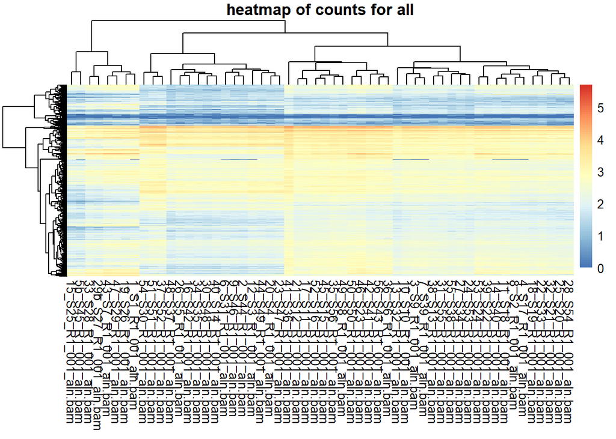

```r
counts[,-(1:6)] %>%
    add(1) %>%
    log10() %>%
    pheatmap(main = "heatmap of counts for all",show_rownames = FALSE)
```

# Prepare data

```r
Data_set <-counts[,-(1:6)] %>%
    add(1) %>%
    log10()
```

# hclust analysis

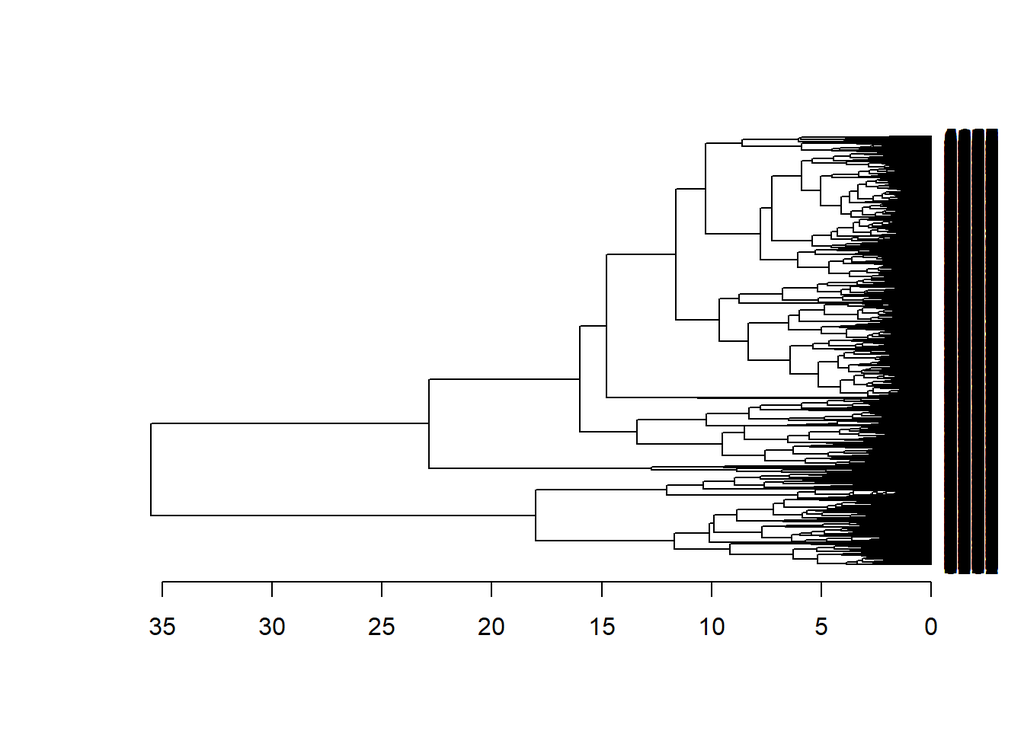

```r
my_hclust_gene <- hclust(dist(Data_set), method = "complete")
as.dendrogram(my_hclust_gene) %>%
  plot(horiz = TRUE)
```

# Cutree

```r
my_gene_col <- cutree(tree = as.dendrogram(my_hclust_gene), k = 2)
my_gene_col <- data.frame(cluster = ifelse(test = my_gene_col == 1, yes = "cluster 1", no = "cluster 2"))
head(my_gene_col)
```

```
##     cluster
## 1 cluster 1
## 2 cluster 1
## 3 cluster 1
## 4 cluster 1
## 5 cluster 1
## 6 cluster 1
```

# Load samplesheet with metadata

Use ‘read_csv’ to read in sample sheet with metadata.

```r
samplesheet <-
  read_csv("~/Documents/GitHub/CryptoGat201RNASeq_draft/input_experiment/Gat201_samplesheet.csv") %>%
  mutate(Group = factor(Group,
              levels = c("A_Y_0", "A_R_30", "A_R_120", "A_R_240", "A_RS_30", "A_RS_120", "A_RS_240", "a_Y_0", "a_R_30", "a_R_120", "a_R_240", "a_RS_30", "a_RS_120", "a_RS_240", "B_Y_0", "B_R_30", "B_R_120", "B_R_240", "B_RS_30", "B_RS_120", "B_RS_240", "M_Y_0", "M_R_30", "M_R_120", "M_R_240", "M_RS_30", "M_RS_120", "M_RS_240")))
samplesheet
```

```
## # A tibble: 56 x 8
##    SampleID BioRep Media  Timepoint Group    Strain Condition  Time
##    <chr>     <dbl> <chr>      <dbl> <fct>    <chr>  <chr>     <dbl>
##  1 1             1 YPD            0 A_Y_0    A      Y             0
##  2 2             1 RPMI          30 A_R_30   A      R            30
##  3 3             1 RPMI         120 A_R_120  A      R           120
##  4 4             1 RPMI         240 A_R_240  A      R           240
##  5 5b            2 YPD            0 A_Y_0    A      Y             0
##  6 6             2 RPMI          30 A_R_30   A      R            30
##  7 7             2 RPMI         120 A_R_120  A      R           120
##  8 8             2 RPMI         240 A_R_240  A      R           240
##  9 9             1 RPMI+S        30 A_RS_30  A      RS           30
## 10 10            1 RPMI+S       120 A_RS_120 A      RS          120
## # ... with 46 more rows
```

# Make a tidy long-format count table, including normalized TPM values and Fold Change

This data is used to make plots etc.

Removing stuff: from ‘set_names’

Group by sample as df : from ‘group_by’

Normalization: from ‘mutate’

This is calculated from the actual count for each row /sum of all genes in that sample (sample ID) x 1e6 to give TPM (ratio so units do not matter).

We can do this because our reads are at 3 end.

For RNASeq using a different method we would have to normalize to the length of each gene as well.

```r
counts_long <- counts %>%
              set_names(str_remove(names(counts), "_R1_001_aln.bam")) %>%
              select(-Chr,-Start,-End,-Strand,-Length) %>%
              pivot_longer(!Geneid,
                            names_to = c("SampleID","SampleNo"), names_sep="_",
                            values_to = "Count") %>%
              group_by(SampleID) %>%
              mutate(TPM = Count / sum(Count) * 1e6) %>%
              ungroup() %>%
              group_by(Geneid) %>%
              mutate(FoldChange = TPM / mean(TPM)) %>%
              ungroup() %>%
              left_join(samplesheet)
counts_long
```

```
## # A tibble: 380,520 x 13
##    Geneid  SampleID SampleNo Count   TPM FoldChange BioRep Media Timepoint Group
##    <chr>   <chr>    <chr>    <dbl> <dbl>      <dbl>  <dbl> <chr>     <dbl> <fct>
##  1 CNAG_0~ 15       S25        184 102.       0.611      1 YPD           0 a_Y_0
##  2 CNAG_0~ 38       S13        452 106.       0.635      1 RPMI~       120 B_RS~
##  3 CNAG_0~ 26       S5        1652 395.       2.36       2 RPMI~        30 a_RS~
##  4 CNAG_0~ 55       S38        403 102.       0.611      2 RPMI~       120 M_RS~
##  5 CNAG_0~ 25       S20        172  47.8      0.285      1 RPMI~       240 a_RS~
##  6 CNAG_0~ 43       S7         738 152.       0.910      1 YPD           0 M_Y_0
##  7 CNAG_0~ 44       S49       2011 413.       2.47       1 RPMI         30 M_R_~
##  8 CNAG_0~ 18       S19        207  62.2      0.372      1 RPMI        240 a_R_~
##  9 CNAG_0~ 41       S36       1099  95.4      0.570      2 RPMI~       120 B_RS~
## 10 CNAG_0~ 50       S50        761  88.7      0.530      2 RPMI        240 M_R_~
## # ... with 380,510 more rows, and 3 more variables: Strain <chr>,
## #   Condition <chr>, Time <dbl>
```

# Write long-format counts to an output file

This is very long because for each gene we have lots of info.

```r
counts_long %>%
    select(Geneid,SampleID,Strain,Condition,Time,BioRep,Count,TPM) %>%
    mutate(TPM = round(TPM, digits = 3)) %>%
    write_tsv("~/Documents/GitHub/CryptoGat201RNASeq_draft/results_counts/counts_tpms_longformat.txt")
```

# Define a function to plot TPMs for a select list of genes

Write as a function so only have to change gene names once on line 170

```r
plot_tpm_somegenes <- function(mygenes = c("CNAG_01551","CNAG_06917"),
                               mydata = counts_long) {
    ggplot(data = filter(mydata, Geneid %in% mygenes),
           aes(colour = Geneid, x = Group, y = TPM)) +
        geom_point(position=position_jitter(width=0.25)) +
        stat_summary(fun.min="mean",fun.max="mean",
                     geom="errorbar",size=1,width=0.5,
                     aes(group=Geneid)) +
        scale_y_log10() +
        labs(y="RNA abundance (TPM)", colour="Gene") +
        theme_cowplot(font_size = 12) +
        theme(axis.text.x = element_text(angle = 90),
              axis.title.x = element_blank(),
              panel.grid.major.y = element_line(colour="grey80"))
}
```

# Plot TPMs for two genes: Change genes in code above line 170

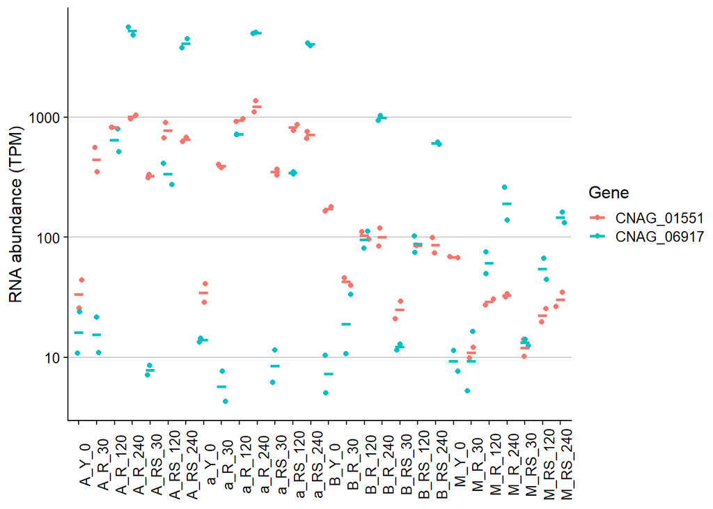

```r
plot_tpm_somegenes()
```

# Remember to change name to genes from line 170

```r
ggsave("~/Documents/GitHub/CryptoGat201RNASeq_draft/results_counts/TPM_Gat201_TSA3.pdf",
       width = 5,height=4)
```

# Reshape the TPMs into a “wide” table that we can use for heatmap

This reshapse ‘counts_long’ using ‘pivot_wider’

‘id_cols’ is what to call the new columns

‘Geneid’ take names used from ‘SampleID’ and the values used from ‘TPM’

```r
tpms_wide <- counts_long %>%
              pivot_wider(id_cols = Geneid, names_from = SampleID, values_from = TPM)
```

# Plot a clustered heatmap of normalized TPMs

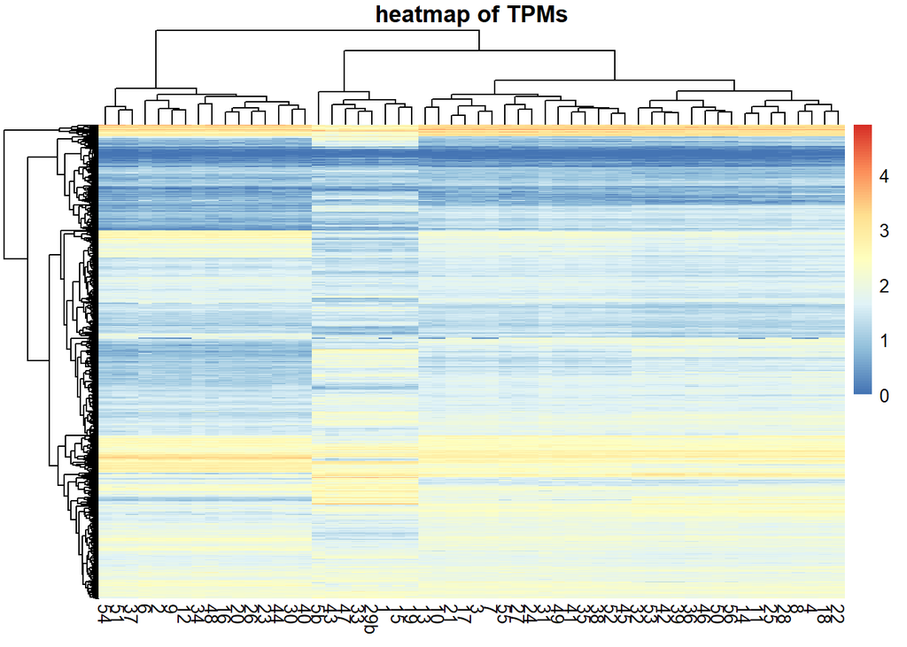

```r
tpms_wide[,-1] %>%
    add(1) %>%
    log10() %>%
    pheatmap(main = "heatmap of TPMs",show_rownames = FALSE)
```

# Plot scatter plots between all pairs of samples (careful, this code runs VERY slowly)

tpms_wide[,-1] %>% add(1) %>% log10() %>% ggpairs()

tpms_wide[,-1] %>% add(1) %>% log10() %>% ggpairs()

# Calculate a summary table of mean, min, max TPM by gene

```r
genesummary <-
    counts_long %>%
    group_by(Geneid) %>%
    summarise(TPM.mean = mean(TPM), TPM.min = min(TPM), TPM.max = max(TPM))
genesummary
```

```
## # A tibble: 6,795 x 4
##    Geneid     TPM.mean TPM.min TPM.max
##    <chr>         <dbl>   <dbl>   <dbl>
##  1 CNAG_00002    167.    47.8    427.
##  2 CNAG_00003     29.9   12.6     85.1
##  3 CNAG_00004     48.9   27.0     90.0
##  4 CNAG_00005    111.    46.0    247.
##  5 CNAG_00006    241.   106.     388.
##  6 CNAG_00007     99.4   24.6    158.
##  7 CNAG_00008     78.6   48.4    139.
##  8 CNAG_00009     45.8   12.6    194.
##  9 CNAG_00010    147.    59.4    320.
## 10 CNAG_00011     21.7    5.74    70.0
## # ... with 6,785 more rows
```

```r
genesummary2<-
  counts_long %>%
  group_by(Geneid) %>%
  summarise(TPM.max = max(TPM)) %>%
  arrange(desc(TPM.max))
genesummary2
```

```
## # A tibble: 6,795 x 2
##    Geneid     TPM.max
##    <chr>        <dbl>
##  1 CNAG_04105  81227.
##  2 CNAG_04687  59073.
##  3 CNAG_06207  30464.
##  4 CNAG_06347  23751.
##  5 CNAG_06298  18780.
##  6 CNAG_01117  18092.
##  7 CNAG_06125  17935.
##  8 CNAG_02775  14791.
##  9 CNAG_00848  14308.
## 10 CNAG_06388  13095.
## # ... with 6,785 more rows
```

# Create lists with TPM values all above thresholds

```r
genelist_mintpm20 <- filter(genesummary,TPM.min > 20)$Geneid
genelist_mintpm100 <- filter(genesummary,TPM.min > 100)$Geneid
genelist_mintpm500 <- filter(genesummary,TPM.min > 500)$Geneid
genelist_mintpm500
```

```
##  [1] "CNAG_00457" "CNAG_00819" "CNAG_00897" "CNAG_01019" "CNAG_01117"
##  [6] "CNAG_01150" "CNAG_01181" "CNAG_01361" "CNAG_01621" "CNAG_01648"
## [11] "CNAG_01727" "CNAG_01750" "CNAG_01761" "CNAG_01920" "CNAG_01984"
## [16] "CNAG_01985" "CNAG_02091" "CNAG_02266" "CNAG_02359" "CNAG_02367"
## [21] "CNAG_03012" "CNAG_03127" "CNAG_03303" "CNAG_03739" "CNAG_04054"
## [26] "CNAG_04105" "CNAG_04448" "CNAG_04687" "CNAG_04828" "CNAG_05696"
## [31] "CNAG_05799" "CNAG_06000" "CNAG_06101" "CNAG_06113" "CNAG_06125"
## [36] "CNAG_06167"
```

# Reshape the fold changes into a “wide” table to use for heatmap and PCA

```r
foldchange_wide <- counts_long %>%
    pivot_wider(id_cols = Geneid, names_from = SampleID, values_from = FoldChange)
```

# Plot a clustered heatmap of fold changes, for genes with mininum TPM 20

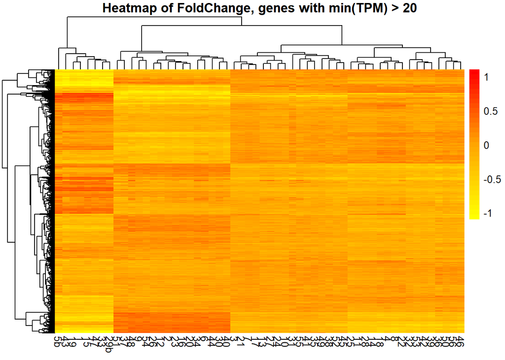

```r
Heatmap <- foldchange_wide %>%
    filter(Geneid %in% genelist_mintpm20) %>%
    .[,-1] %>%
    log10() %>%
    pheatmap(main = "Heatmap of FoldChange, genes with min(TPM) > 20",show_rownames = FALSE,
             color = colorRampPalette(c("yellow", "orange","red"))(31),
             breaks = seq(-1.1,1.1,length=32))
```

# To print heatmap above

```r
ggsave("~/Documents/GitHub/CryptoGat201RNASeq_draft/results_counts/Heatmap_Foldchange_mintpm20.jpeg",)
```

The 4 main clusters are slpit by time.

1. YO
2. R/RS 30 min
3. R/RS 120 min
4. R/RS 240 min

# Principal Component Analysis

## For genes with min. TPM 20

```r
pca_log10foldchange_mintpm20 <-
    foldchange_wide %>%
    filter(Geneid %in% genelist_mintpm20) %>%
    .[,-1] %>%
    log10() %>%
    prcomp(scale=TRUE)
```

## Plot first and second principal components by sample

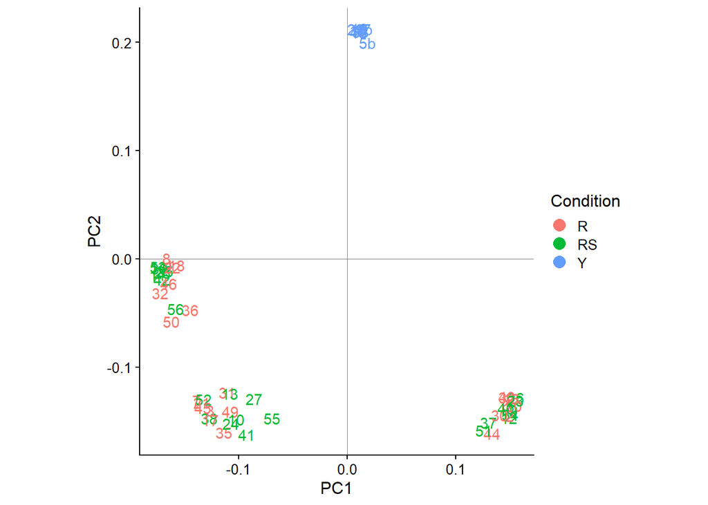

```r
plot_pca_log10foldchange_mintpm20_PC12 <-
pca_log10foldchange_mintpm20 %>%
    broom::tidy(matrix = "rotation") %>%
    rename(SampleID=column) %>%
    left_join(samplesheet) %>%
    pivot_wider(names_from = "PC", names_prefix = "PC", values_from = "value") %>%
    ggplot(aes(PC1, PC2)) +
    geom_vline(aes(xintercept = 0),size=0.2,colour = "grey50") +
    geom_hline(aes(yintercept = 0),size=0.2,colour = "grey50")  +
    geom_text(
        aes(label = SampleID,colour=Condition),
        key_glyph = "point"
    ) +
    coord_equal()
ggsave("~/Documents/GitHub/CryptoGat201RNASeq_draft/results_counts/plot_pca_log10foldchange_mintpm20_PC12.pdf",
       plot_pca_log10foldchange_mintpm20_PC12,width = 4,height=4)
plot_pca_log10foldchange_mintpm20_PC12
```

Blue = Y at 0 min.

Green/Red Top Left = R/RS at 4 hours.

Green/Red Bottom Left = R.RS at 2 hours.

Green/Red at Bottom Right = R/Rs at 30 min.

## Plot second and third principal components by sample

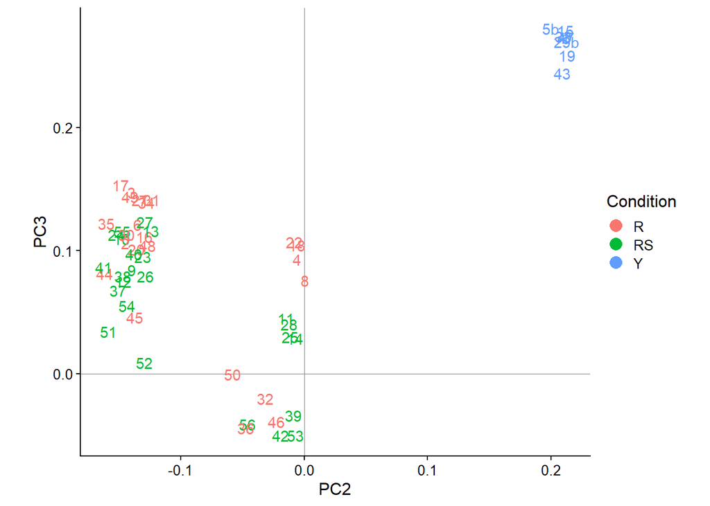

```r
plot_pca_log10foldchange_mintpm20_PC23 <-
pca_log10foldchange_mintpm20 %>%
    broom::tidy(matrix = "rotation") %>%
    rename(SampleID=column) %>%
    left_join(samplesheet) %>%
    pivot_wider(names_from = "PC", names_prefix = "PC", values_from = "value") %>%
    ggplot(aes(PC2, PC3)) +
    geom_vline(aes(xintercept = 0),size=0.2,colour = "grey50") +
    geom_hline(aes(yintercept = 0),size=0.2,colour = "grey50")  +
    geom_text(
        aes(label = SampleID,colour=Condition),
        key_glyph = "point"
    ) +
    coord_equal()
plot_pca_log10foldchange_mintpm20_PC23
```

```r
ggsave("~/Documents/GitHub/CryptoGat201RNASeq_draft/results_counts/plot_pca_log10foldchange_mintpm20_PC23.jpeg",
       plot_pca_log10foldchange_mintpm20_PC23,width = 4,height=4)
```

Blue = Y at 0 min.

Red Top Right(4,8,18,22) =KN99 A/a R at 4 hours.

Green Mid right (11,14,25,28) = KN99 A/a RS at 4 hours.

Red Mid Right (32,36,46,50) = Gat201 B/M R at 4 hours.

Green Bottom Right (39,42,53,56) = Gat201 B/M RS at 4 hours.

Red/Green collected at the Left Side = Mix of 30 min and 2 hours for all 4 strains with slight media separation.

## Plot third and fourth principal components by sample

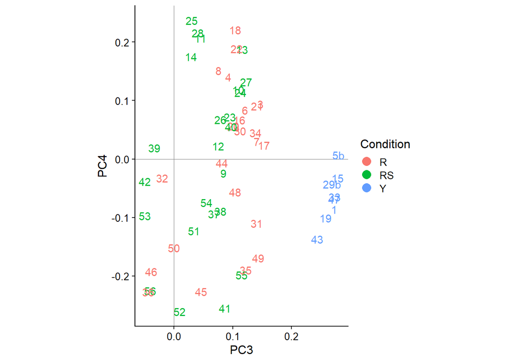

```r
plot_pca_log10foldchange_mintpm20_PC34 <-
pca_log10foldchange_mintpm20 %>%
    broom::tidy(matrix = "rotation") %>%
    rename(SampleID=column) %>%
    left_join(samplesheet) %>%
    pivot_wider(names_from = "PC", names_prefix = "PC", values_from = "value") %>%
    ggplot(aes(PC3, PC4)) +
    geom_vline(aes(xintercept = 0),size=0.2,colour = "grey50") +
    geom_hline(aes(yintercept = 0),size=0.2,colour = "grey50")  +
    geom_text(
        aes(label = SampleID,colour=Condition),
        key_glyph = "point"
    ) +
    coord_equal()
plot_pca_log10foldchange_mintpm20_PC34
```

```r
ggsave("~/Documents/GitHub/CryptoGat201RNASeq_draft/results_counts/plot_pca_log10foldchange_mintpm20_PC34.pdf",
       plot_pca_log10foldchange_mintpm20_PC34,width = 4,height=4)
```

Blue = Y at 0 mis.

39,42,53,56 (Green) = Gat201 B/M RS at 4 hours.

32,36,46,50 (Red) = Gat201 B/M R at 4 hours.

11,14,25,28 (Green) = KN99A/a RS at 4 hours.

4,8,18,22 (Red) = KN99A/a R at 4 hours.

38,41,52,55 (Green) = Gat201 B/M RS at 2 hours.

37,40,51,54 (Green) = Gat201 B/M RS at 30 min.

## Plot PCA loadings, i.e. percent variance explained by each PC

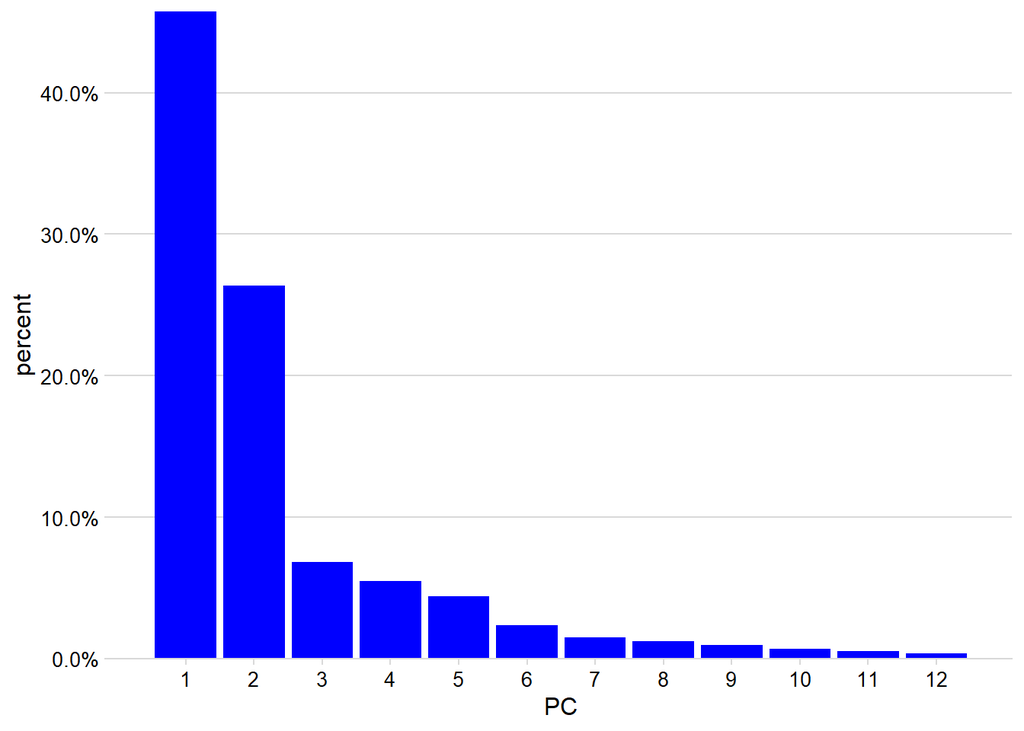

```r
plot_pcaloading_log10foldchange_mintpm20 <-
pca_log10foldchange_mintpm20 %>%
    broom::tidy(matrix = "d") %>%
    ggplot(aes(PC, percent)) +
    geom_col(fill="blue")   +
    scale_x_continuous(breaks = 1:12,limits = c(0.5,12.5)) +
    scale_y_continuous(
        labels = scales::percent_format(),
        expand = c(0, 0)
    ) +
    theme_minimal_hgrid(12)

plot_pcaloading_log10foldchange_mintpm20
```

```r
ggsave("~/Documents/GitHub/CryptoGat201RNASeq_draft/results_counts/plot_pcaloading_log10foldchange_mintpm20.jpeg",
       plot_pcaloading_log10foldchange_mintpm20,width = 4,height=4)
```

# Summarize TPMs by Group (i.e. groups of replicates for the same condition)

```r
tpms_bygroup <-
    counts_long  %>%
    group_by(Geneid,Group,Media,Time,Condition,Strain) %>%
    summarise(TPM = mean(TPM), FoldChange = mean(FoldChange))
tpms_bygroup
```

```
## # A tibble: 190,260 x 8
## # Groups:   Geneid, Group, Media, Time, Condition [190,260]
##    Geneid     Group    Media   Time Condition Strain   TPM FoldChange
##    <chr>      <fct>    <chr>  <dbl> <chr>     <chr>  <dbl>      <dbl>
##  1 CNAG_00002 A_Y_0    YPD        0 Y         A       79.1      0.473
##  2 CNAG_00002 A_R_30   RPMI      30 R         A      365.       2.18
##  3 CNAG_00002 A_R_120  RPMI     120 R         A       95.0      0.567
##  4 CNAG_00002 A_R_240  RPMI     240 R         A       57.9      0.346
##  5 CNAG_00002 A_RS_30  RPMI+S    30 RS        A      329.       1.96
##  6 CNAG_00002 A_RS_120 RPMI+S   120 RS        A       90.4      0.540
##  7 CNAG_00002 A_RS_240 RPMI+S   240 RS        A       49.9      0.298
##  8 CNAG_00002 a_Y_0    YPD        0 Y         a       99.8      0.596
##  9 CNAG_00002 a_R_30   RPMI      30 R         a      382.       2.28
## 10 CNAG_00002 a_R_120  RPMI     120 R         a      103.       0.613
## # ... with 190,250 more rows
```

# Make wide-format mean TPMs by group, to use for scatter plots

```r
tpms_bygroup_wide <- tpms_bygroup %>%
    pivot_wider(id_cols = Geneid, names_from = Group, values_from = TPM)
```

# Plot mean TPMs

It gets messy from here on in…bear with me

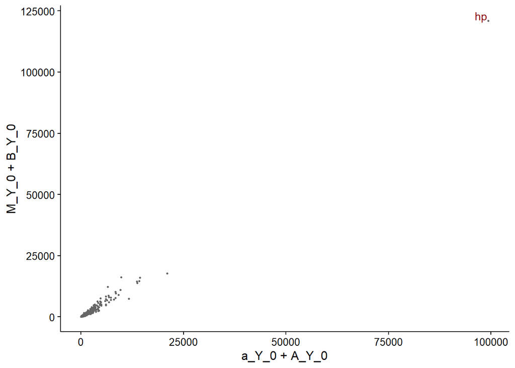

```r
ggplot(data = tpms_bygroup_wide,
       aes(x=a_Y_0 + A_Y_0,y=M_Y_0 + B_Y_0))+
  geom_point(colour = "grey40", size = 0.5)+
   geom_text(data = filter(tpms_bygroup_wide,Geneid =="CNAG_04105"),
              label="hp",hjust = 1.1,vjust = -0.1, colour= "darkred")
```

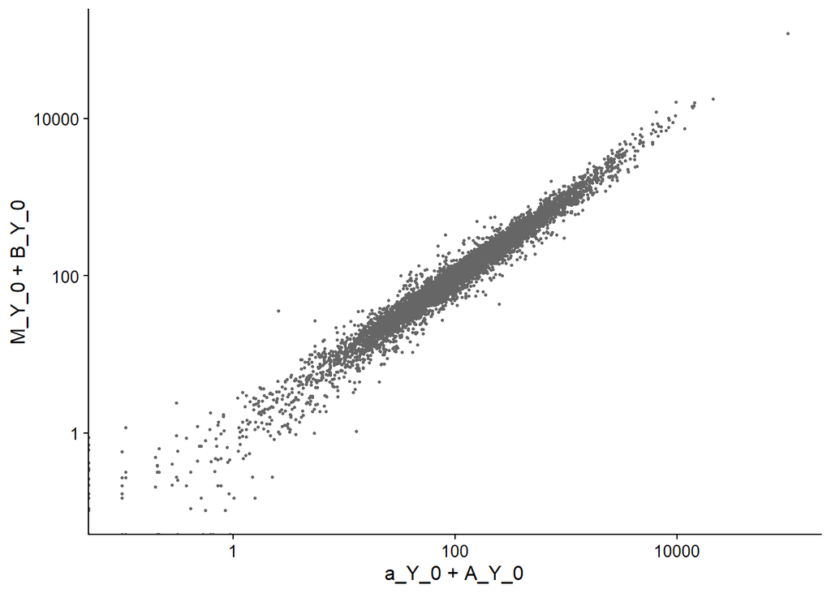

```r
ggplot(data = tpms_bygroup_wide,
       aes(x=a_Y_0 + A_Y_0,y=M_Y_0 + B_Y_0))+
    geom_point(colour = "grey40", size = 0.5, )+
  scale_x_log10("a_Y_0 + A_Y_0") + scale_y_log10("M_Y_0 + B_Y_0")
```

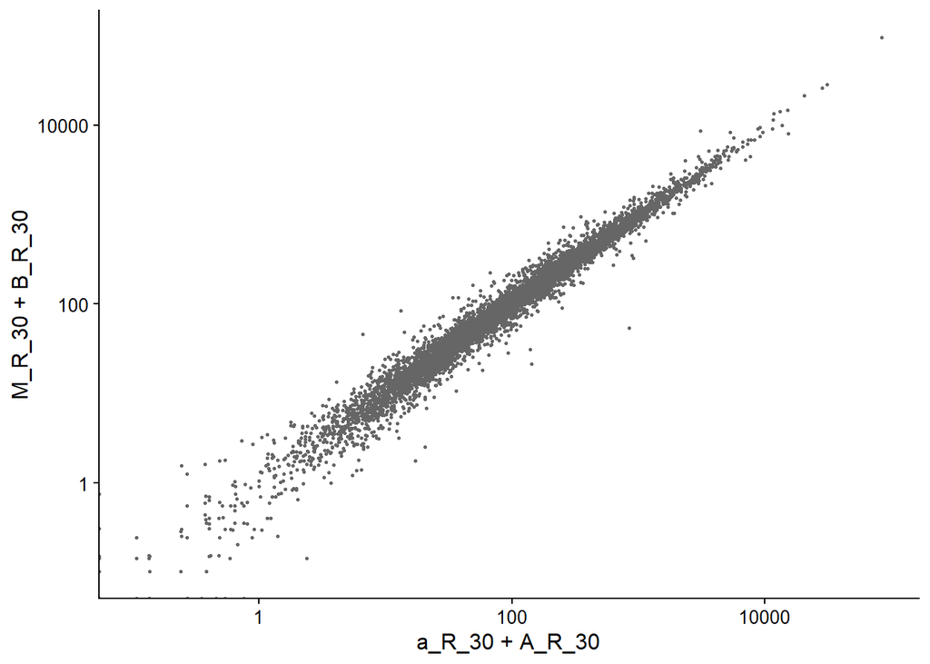

```r
ggplot(data = tpms_bygroup_wide,
       aes(x=a_R_30 + A_R_30,y=M_R_30 + B_R_30))+
       geom_point(colour = "grey40", size = 0.5, )+
       scale_x_log10("a_R_30 + A_R_30") + scale_y_log10("M_R_30 + B_R_30")
```

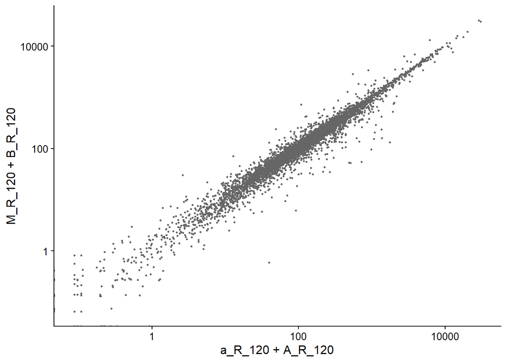

```r
ggplot(data = tpms_bygroup_wide,
       aes(x=a_R_120 + A_R_120,y=M_R_120 + B_R_120))+
       geom_point(colour = "grey40", size = 0.5, )+
       scale_x_log10("a_R_120 + A_R_120") + scale_y_log10("M_R_120 + B_R_120")
```

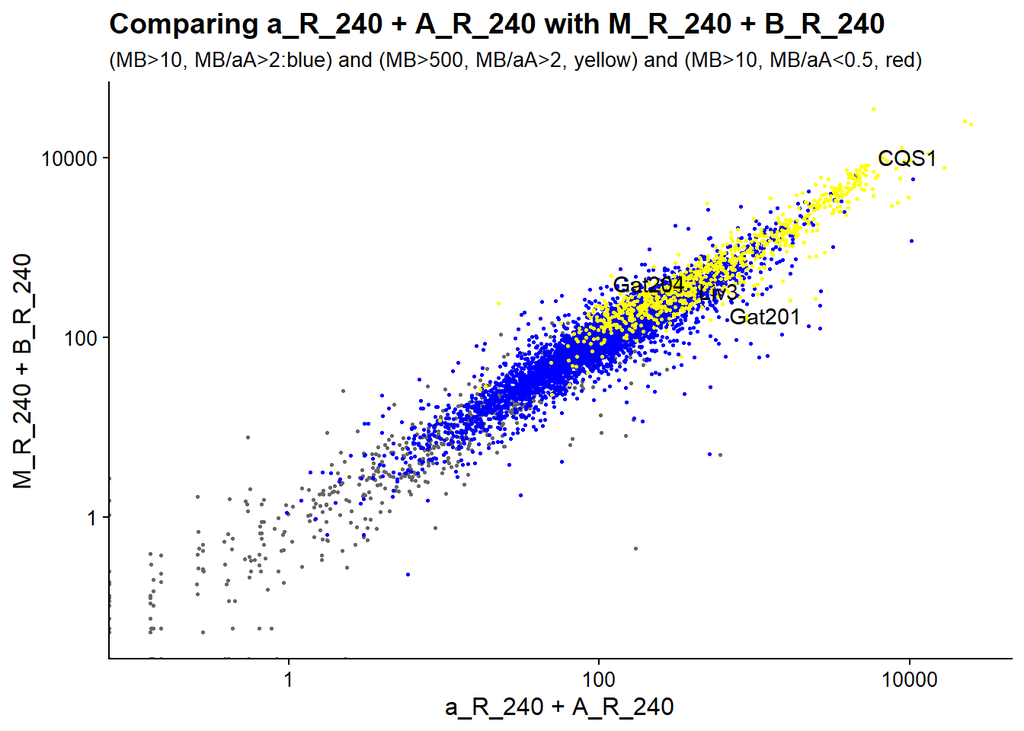

```r
ggplot(data = tpms_bygroup_wide,
       aes(x=a_R_240 + A_R_240,y=M_R_240 + B_R_240))+
       geom_point(colour = "grey40", size = 0.5, )+
  geom_point(data = filter(tpms_bygroup_wide,
                             M_R_30 + B_R_30 > 10,
                             M_R_30 + B_R_30/a_R_30 + A_R_30 > 2 ),
               colour = "blue", size = 0.5) +
    geom_point(data = filter(tpms_bygroup_wide,
                             M_R_30 + B_R_30 > 500,
                             M_R_30 + B_R_30/a_R_30 + A_R_30 > 2 ),
               colour = "yellow", size = 0.5) +
  geom_point(data = filter(tpms_bygroup_wide,
                             M_R_30 + B_R_30 > 10,
                             M_R_30 + B_R_30/a_R_30 + A_R_30 < 0.5 ),
               colour = "red", size = 0.5) +
    geom_text(data = filter(tpms_bygroup_wide,Geneid =="CNAG_01551"),
              label="Gat201",hjust = 1.1,vjust = -0.1, colour= "black") +
    geom_text(data = filter(tpms_bygroup_wide,Geneid =="CNAG_06762"),
              label="Gat204",hjust = 2,vjust = -0.1, colour= "black") +
    geom_text(data = filter(tpms_bygroup_wide,Geneid =="CNAG_05835"),
              label="Liv3",hjust = 1.1,vjust = -0.1, colour= "black") +
    geom_text(data = filter(tpms_bygroup_wide,Geneid =="CNAG_03012"),
              label="CQS1",hjust = 1.1,vjust = -0.1, colour= "black") +
   labs(title="Comparing a_R_240 + A_R_240 with M_R_240 + B_R_240",#
        subtitle = "(MB>10, MB/aA>2:blue) and (MB>500, MB/aA>2, yellow) and (MB>10, MB/aA<0.5, red)")+
scale_x_log10("a_R_240 + A_R_240") + scale_y_log10("M_R_240 + B_R_240")
```

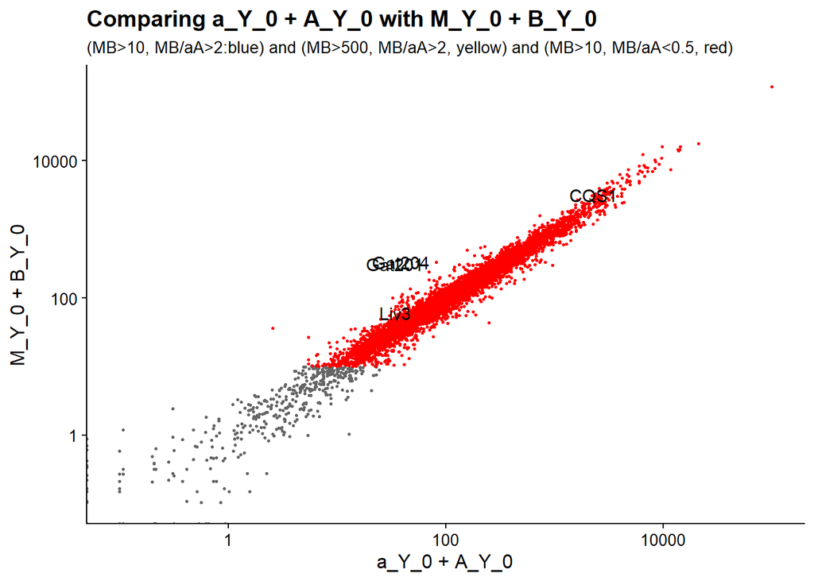

```r
ggplot(data = tpms_bygroup_wide,
       aes(x=a_Y_0 + A_Y_0,y=M_Y_0 + B_Y_0))+
       geom_point(colour = "grey40", size = 0.5, )+
  geom_point(data = filter(tpms_bygroup_wide,
                           M_Y_0 + B_Y_0 > 10,
                           M_Y_0 + B_Y_0 / a_Y_0 + A_Y_0 >2),
               colour = "blue", size = 0.5) +
    geom_point(data = filter(tpms_bygroup_wide,
                             M_Y_0 + B_Y_0 > 500,
                           M_Y_0 + B_Y_0 / a_Y_0 + A_Y_0 >2),
               colour = "yellow", size = 0.5) +
  geom_point(data = filter(tpms_bygroup_wide,
                             M_Y_0 + B_Y_0 > 10,
                           M_Y_0 + B_Y_0 / a_Y_0 + A_Y_0 >0.5),
               colour = "red", size = 0.5) +
    geom_text(data = filter(tpms_bygroup_wide,Geneid =="CNAG_01551"),
              label="Gat201",hjust = 1.1,vjust = -0.1, colour= "black") +
    geom_text(data = filter(tpms_bygroup_wide,Geneid =="CNAG_06762"),
              label="Gat204",hjust = 2,vjust = -0.1, colour= "black") +
    geom_text(data = filter(tpms_bygroup_wide,Geneid =="CNAG_05835"),
              label="Liv3",hjust = 1.1,vjust = -0.1, colour= "black") +
    geom_text(data = filter(tpms_bygroup_wide,Geneid =="CNAG_03012"),
              label="CQS1",hjust = 1.1,vjust = -0.1, colour= "black") +
   labs(title="Comparing a_Y_0 + A_Y_0 with M_Y_0 + B_Y_0",#
        subtitle = "(MB>10, MB/aA>2:blue) and (MB>500, MB/aA>2, yellow) and (MB>10, MB/aA<0.5, red)")+
scale_x_log10("a_Y_0 + A_Y_0") + scale_y_log10("M_Y_0 + B_Y_0")
```

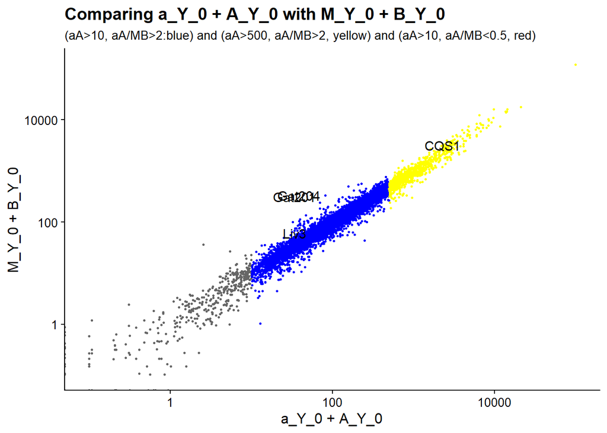

```r
ggplot(data = tpms_bygroup_wide,
       aes(x=a_Y_0 + A_Y_0,y=M_Y_0 + B_Y_0))+
       geom_point(colour = "grey40", size = 0.5, )+
  geom_point(data = filter(tpms_bygroup_wide,
                           a_Y_0 + A_Y_0 > 10,
                           a_Y_0 + A_Y_0 /M_Y_0 + B_Y_0 > 2),
               colour = "blue", size = 0.5) +

    geom_point(data = filter(tpms_bygroup_wide,
                           a_Y_0 + A_Y_0 > 500,
                           a_Y_0 + A_Y_0 /M_Y_0 + B_Y_0 > 2),
               colour = "yellow", size = 0.5) +

  geom_point(data = filter(tpms_bygroup_wide,
                           a_Y_0 + A_Y_0 > 10,
                           a_Y_0 + A_Y_0 /M_Y_0 + B_Y_0 < 0.5),
               colour = "red", size = 0.5) +
    geom_text(data = filter(tpms_bygroup_wide,Geneid =="CNAG_01551"),
              label="Gat201",hjust = 1.1,vjust = -0.1, colour= "black") +
    geom_text(data = filter(tpms_bygroup_wide,Geneid =="CNAG_06762"),
              label="Gat204",hjust = 2,vjust = -0.1, colour= "black") +
    geom_text(data = filter(tpms_bygroup_wide,Geneid =="CNAG_05835"),
              label="Liv3",hjust = 1.1,vjust = -0.1, colour= "black") +
    geom_text(data = filter(tpms_bygroup_wide,Geneid =="CNAG_03012"),
              label="CQS1",hjust = 1.1,vjust = -0.1, colour= "black") +
   labs(title="Comparing a_Y_0 + A_Y_0 with M_Y_0 + B_Y_0",#
        subtitle = "(aA>10, aA/MB>2:blue) and (aA>500, aA/MB>2, yellow) and (aA>10, aA/MB<0.5, red)")+
scale_x_log10("a_Y_0 + A_Y_0") + scale_y_log10("M_Y_0 + B_Y_0")
```

```r
ggsave("~/Documents/GitHub/CryptoGat201RNASeq_draft/results_counts/TPMs_aAR240vsMBR240_reverse.png",
       width = 8,height=5)
```

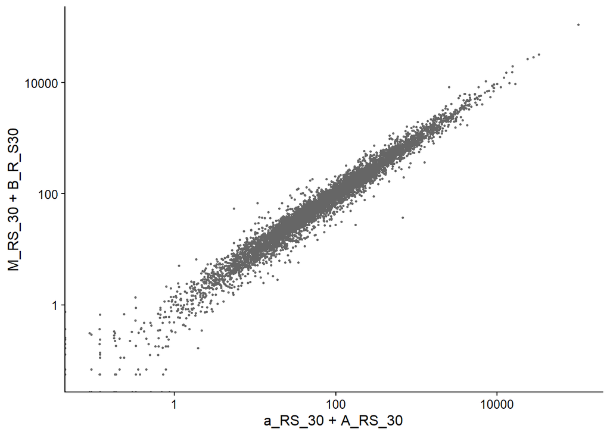

```r
ggplot(data = tpms_bygroup_wide,
       aes(x=a_RS_30 + A_RS_30,y=M_RS_30 + B_RS_30))+
       geom_point(colour = "grey40", size = 0.5, )+
       scale_x_log10("a_RS_30 + A_RS_30") + scale_y_log10("M_RS_30 + B_R_S30")
```

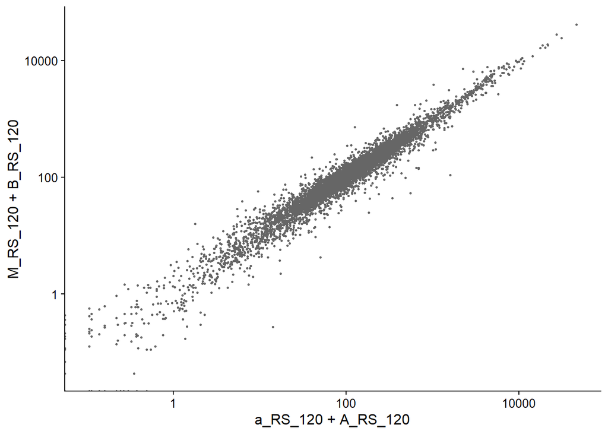

```r
ggplot(data = tpms_bygroup_wide,
       aes(x=a_RS_120 + A_RS_120,y=M_RS_120 + B_RS_120))+
       geom_point(colour = "grey40", size = 0.5, )+
       scale_x_log10("a_RS_120 + A_RS_120") + scale_y_log10("M_RS_120 + B_RS_120")
```

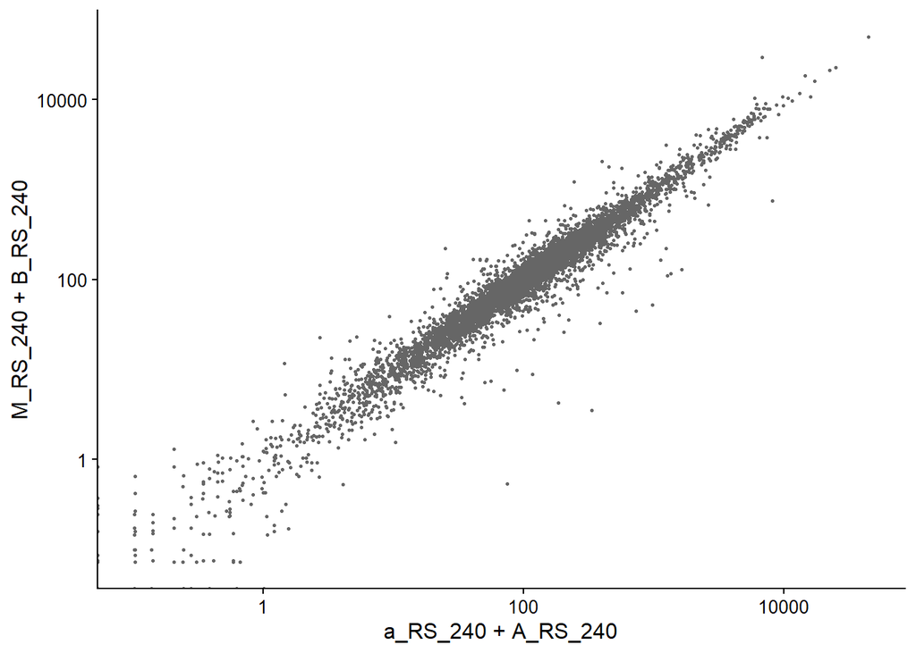

```r
ggplot(data = tpms_bygroup_wide,
       aes(x=a_RS_240 + A_RS_240,y=M_RS_240 + B_RS_240))+
       geom_point(colour = "grey40", size = 0.5, )+
       scale_x_log10("a_RS_240 + A_RS_240") + scale_y_log10("M_RS_240 + B_RS_240")
```